# Lab 3: Data Visualization

Elena Tuzhilina

Sep 28, 2021

Today we’ll be working with a dataset that I downloaded from the [World Bank’s DataBank](https://databank.worldbank.org/home.aspx). The raw dataset from the DataBank is not amenable for direct analysis, so we will be working with a processed version. First, let’s load the `ggplot2` package. (Install the package with `install.packages("ggplot2")` if you have not done so yet.)

```r
library(ggplot2)
```

Next, run the following line of code to get the dataset as a data frame in R. Don’t worry about the syntax; treat this as a magical incantation for now.

```r
df <- read.csv("http://web.stanford.edu/~elenatuz/courses/stats32-aut2021/worldbank_data_tidy.csv",
               stringsAsFactors = FALSE)
```

We use the `str()`, `head()` and `View()` functions to see the dataset:

```r
str(df)
```

```
## 'data.frame':    2170 obs. of  11 variables:
##  $ cty_name  : chr  "Afghanistan" "Afghanistan" "Afghanistan" "Afghanistan" ...
##  $ cty_code  : chr  "AFG" "AFG" "AFG" "AFG" ...
##  $ year      : int  2009 2010 2011 2012 2013 2014 2015 2016 2017 2018 ...
##  $ elecAccess: num  45.2 42.7 43.2 69.1 70.2 ...
##  $ gdpPerCap : num  1455 1637 1627 1807 1875 ...
##  $ compEduc  : int  9 9 9 9 9 9 9 9 9 NA ...
##  $ educPri   : num  NA NA NA NA NA NA NA NA NA NA ...
##  $ educTer   : num  NA NA NA NA NA NA NA NA NA NA ...
##  $ govEducExp: num  NA 3.46 3.44 2.52 3.43 ...
##  $ popYoung  : num  47.9 47.8 47.3 46.7 46 ...
##  $ pop       : int  28394813 29185507 30117413 31161376 32269589 33370794 34413603 35383128 36296400 37172386 ...
```

```r
head(df)
```

```
##      cty_name cty_code year elecAccess gdpPerCap compEduc educPri educTer
## 1 Afghanistan      AFG 2009   45.23712  1454.663        9      NA      NA
## 2 Afghanistan      AFG 2010   42.70000  1637.378        9      NA      NA
## 3 Afghanistan      AFG 2011   43.22202  1626.765        9      NA      NA
## 4 Afghanistan      AFG 2012   69.10000  1806.764        9      NA      NA
## 5 Afghanistan      AFG 2013   70.15348  1874.766        9      NA      NA
## 6 Afghanistan      AFG 2014   89.50000  1897.526        9      NA      NA
##   govEducExp popYoung      pop
## 1         NA 47.90947 28394813
## 2    3.46196 47.79811 29185507
## 3    3.43785 47.34328 30117413
## 4    2.52441 46.73910 31161376
## 5    3.43437 46.03378 32269589
## 6    3.67390 45.28739 33370794
```

Here is a short summary of the variables in the dataset (other than the obvious ones):

- `elecAccess`: % of population with access to electricity.
- `gdpPerCap`: GDP per capita based on purchasing power parity. This is a proxy for how rich a country is.
- `compEduc`: Number of years that children are legally obliged to attend school.
- `educPri`: % of population aged 25 and over that attained or completed primary education.
- `educTer`: % of population aged 25 and over that attained or completed Bachelor’s or equivalent.
- `govEducExp`: General government expenditure on education as a % of GDP.
- `popYoung`: Population between the ages of 0 to 14 as a % of total population.
- `pop`: Total population.

Try out some of the other summary functions we learnt last week. How many possible values does `compEduc` take on? What years does this dataset span?

## Histograms

```
## Warning: Removed 250 rows containing non-finite values (stat_bin).
```

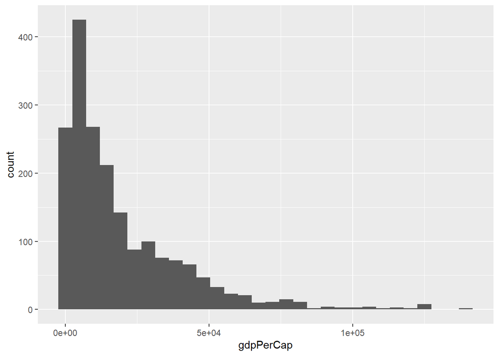

```r
ggplot() +
    geom_histogram(data = df, mapping = aes(x = gdpPerCap))
```

Notice that we received a warning message: “Removed 250 rows containing non-finite values (stat_bin).”. There happened to be 250 rows that had `NA` as the value in the `gdpPerCap` column; R is warning us about it. As a data analyst, it would be a good idea to find out why these rows did not have any data.

If we don’t specify `data` or `mapping` inside the `geom_histogram()` function, it will look for these values in the `ggplot()` function. Hence, the code below will give the same result:

```
## Warning: Removed 250 rows containing non-finite values (stat_bin).
```

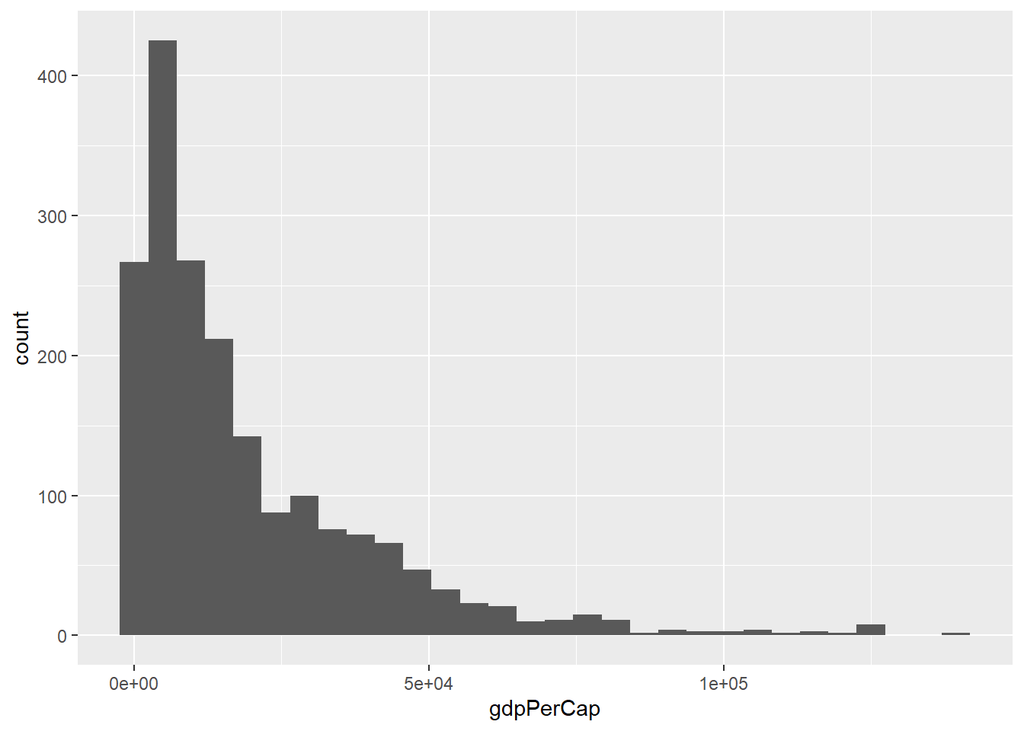

```r
ggplot(data = df, mapping = aes(x = gdpPerCap)) +
    geom_histogram()
```

R defaults to 30 bins for the histogram. We can change this by adding a `bins` argument to `geom_histogram()`. As you can see from the histograms below, different bin widths can give very different interpretations of the data!

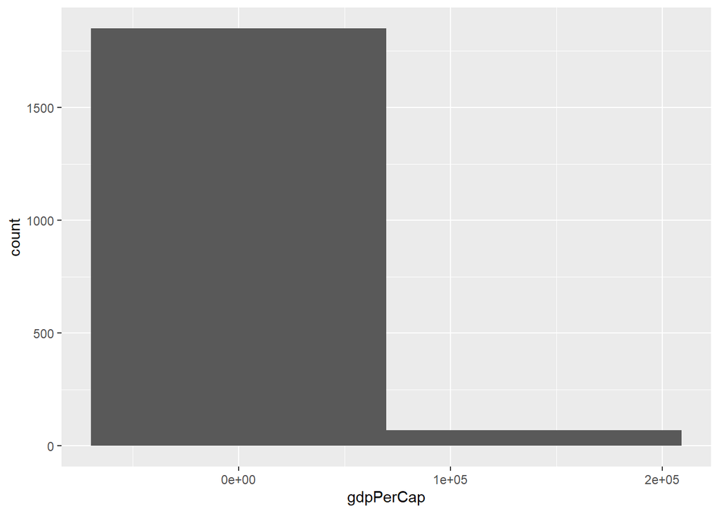

```r
ggplot(data = df) +
    geom_histogram(mapping = aes(x = gdpPerCap), bins = 2)
```

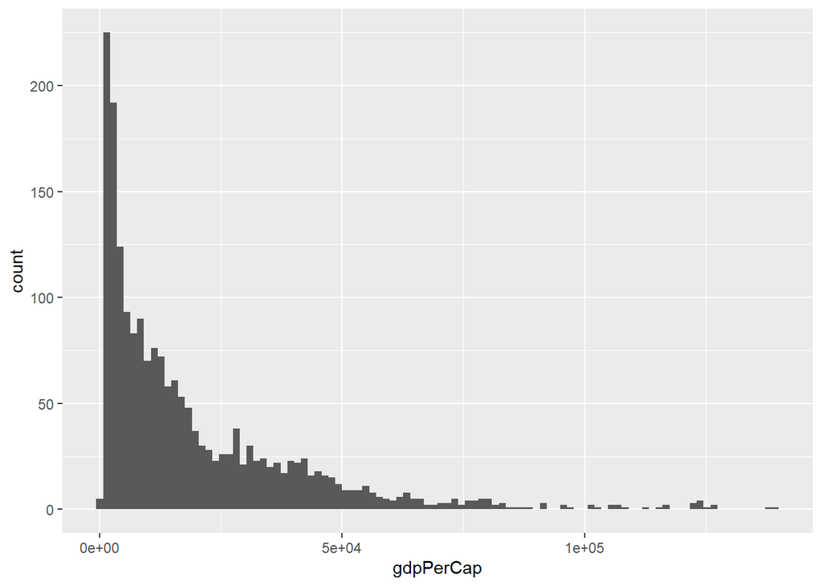

```r
ggplot(data = df) +
    geom_histogram(mapping = aes(x = gdpPerCap), bins = 100)
```

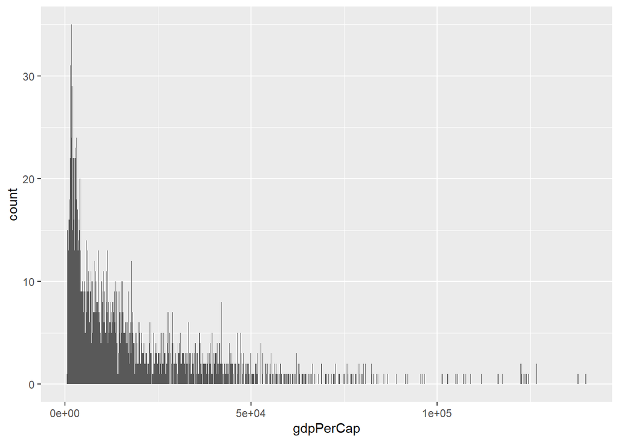

```r
ggplot(data = df) +
    geom_histogram(mapping = aes(x = gdpPerCap), bins = 1000)
```

## Scatterplots

Scatterplots are good for visualizing the relationship between 2 continuous variables. For example, what’s the relationship between primary education attainment and GDP per capita? Let’s make a scatterplot of GDP per capita vs. primary education attainment:

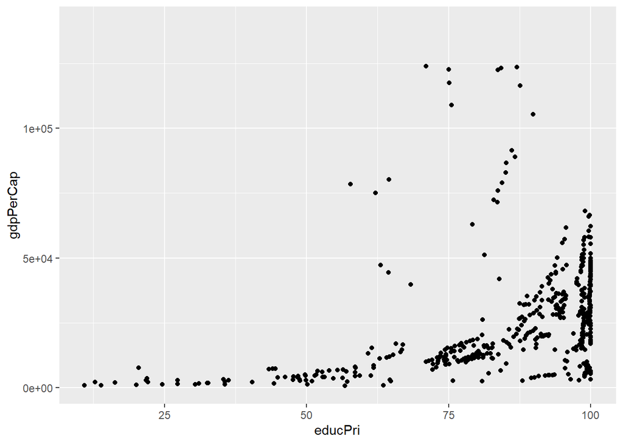

```r
ggplot(data = df) +
    geom_point(mapping = aes(x = educPri, y = gdpPerCap))
```

Wow, what a mess! That’s because we have so many data points being plotted over each other (this is called **overplotting**). Are there more points in the 70-80% range on the x-axis, or in the 95-100% range? It’s hard to tell. One way to address this is to modify the transparency of each point by adjusting “alpha”. By default, `alpha = 1`, which represents being fully opaque. We can reduce alpha (`alpha = 0.2` means that 5 points are needed to get full opacity). Notice that `alpha` is not within the `aes` brackets since it is not determined by the data.

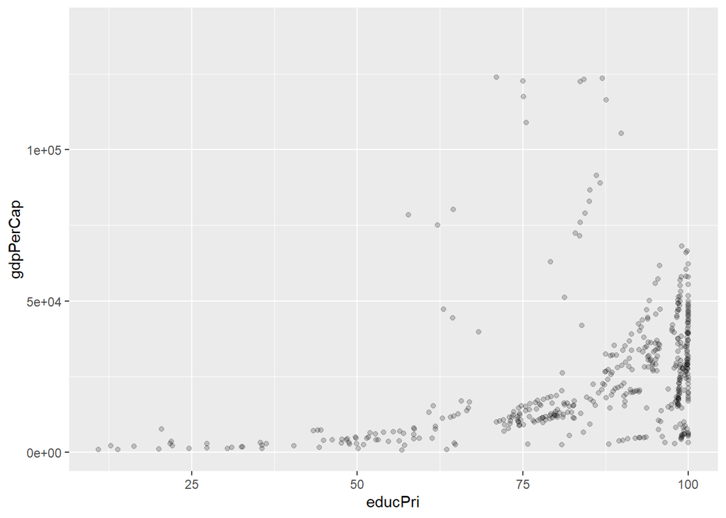

```r
ggplot(data = df) +
    geom_point(mapping = aes(x = educPri, y = gdpPerCap), alpha = 0.2)
```

While `alpha = 0.2` is probably too faint in this case, the characteristics of the data become more obvious.

We see that the scale on the y-axis is somewhat dominated by the points at the top. One way to make the points more spread out across the canvas is to perform a logarithmic transformation on the y-axis:

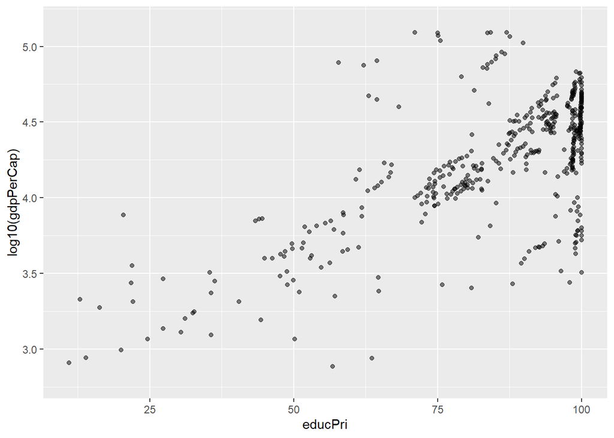

```r
ggplot(data = df) +
    geom_point(mapping = aes(x = educPri, y = log10(gdpPerCap)), alpha = 0.5)
```

There certainly seems to be a positive relationship here, although the range in GDP per capita seems fairly wide when primary education attainment is very high.

Does the relationship change of we look at tertiary education attainment instead? We make this scatterplot below. Instead of filled circles, we could change the shape of the points manually through the `shape` argument (see [this reference](http://r4ds.had.co.nz/data-visualisation.html#fig:shapes) for which symbols correspond to each `shape` value):

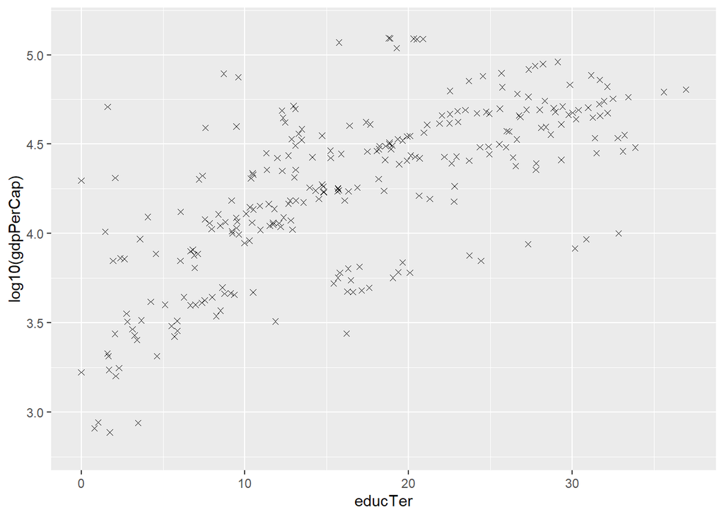

```r
ggplot(data = df) +
    geom_point(mapping = aes(x = educTer, y = log10(gdpPerCap)), shape = 4)
```

Let’s explore another relationship: years of compulsory education vs. GDP per capita. Let’s start with a scatterplot:

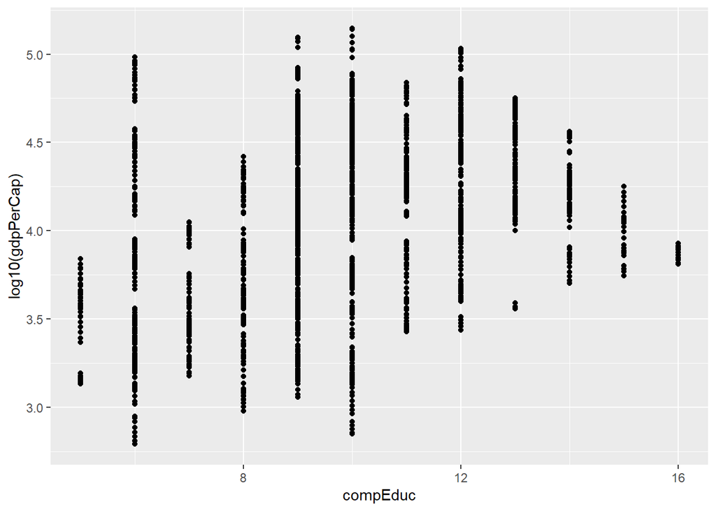

```r
ggplot(data = df) +
    geom_point(mapping = aes(x = compEduc, y = log10(gdpPerCap)))
```

This is not very informative. We see a lot of overplotting going on: and that’s because `compEduc` only takes on a few values. (Because of this, `compEduc` can also be thought of as a categorical variable!) Let’s use the alpha trick that we used previously:

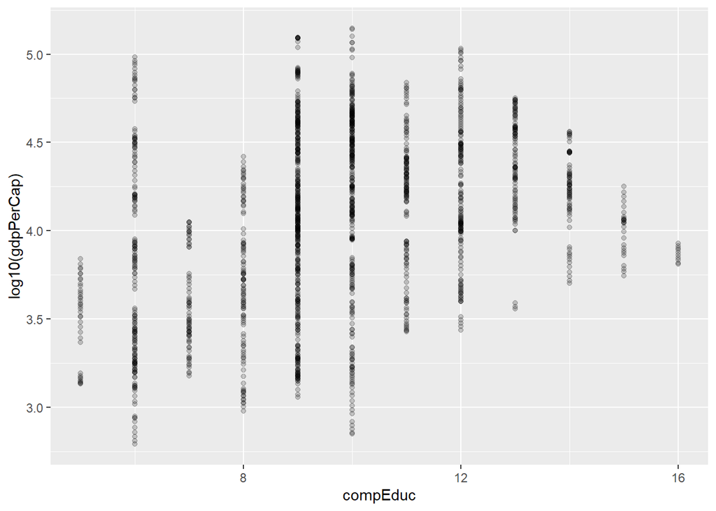

```r
ggplot(data = df) +
    geom_point(mapping = aes(x = compEduc, y = log10(gdpPerCap)), alpha = 0.2)
```

In this case, changing alpha on its own is not going to help much, since all the points are still going to lie on one vertical line. Let’s add **jitter** (i.e. move the points by a small random amount) to get a better view.

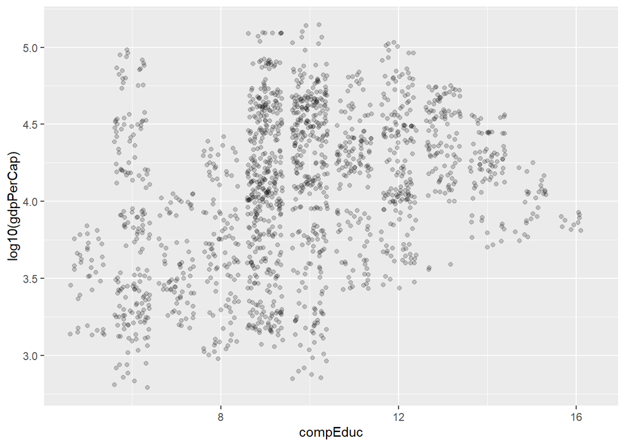

```r
ggplot(data = df) +
    geom_point(mapping = aes(x = compEduc, y = log10(gdpPerCap)),
               alpha = 0.2, position = "jitter")
```

Because jittering is such a common operation, instead of adding `position = "jitter"` as an argument to `geom_point()`, we can use `geom_jitter()` directly to get the same plot:

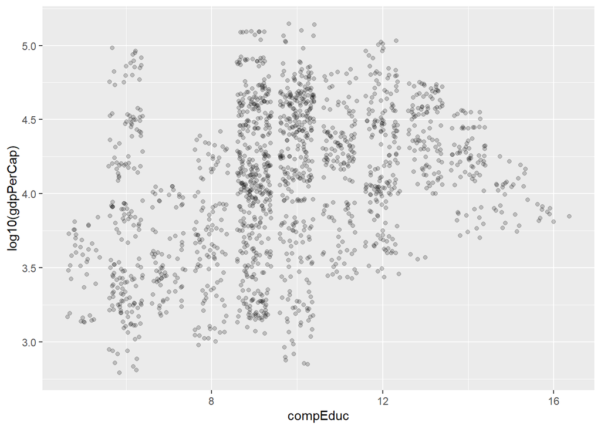

```r
ggplot(data = df) +
    geom_jitter(mapping = aes(x = compEduc, y = log10(gdpPerCap)),
               alpha = 0.2)
```

## Boxplots and violin plots

Because `compEduc` only takes on a few values, we can think of it as a categorical variable. In the plots above, instead of plotting the individual points for each observation, we could draw a boxplot for each value of the categorical variable.

Because `compEduc` is a numeric variable, we need to pass `factor(compEduc)` to the `geom_boxplot()` function instead so that it treats `compEduc` like a categorical variable:

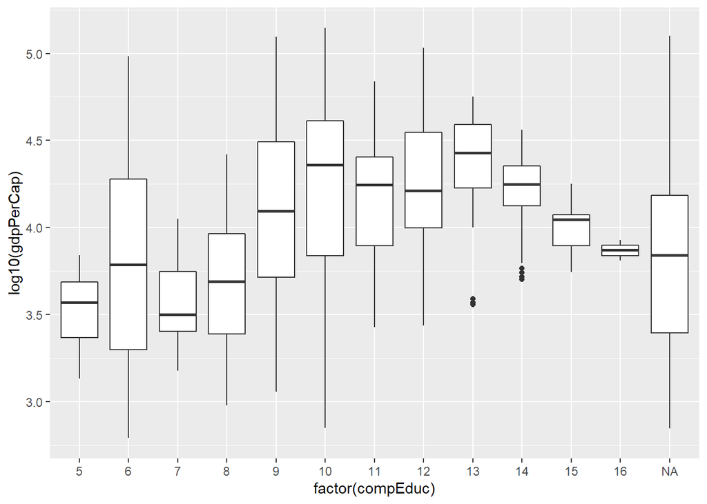

```r
ggplot(data = df) +
    geom_boxplot(mapping = aes(x = factor(compEduc), y = log10(gdpPerCap)))
```

For a violin plot, use `geom_violin()`:

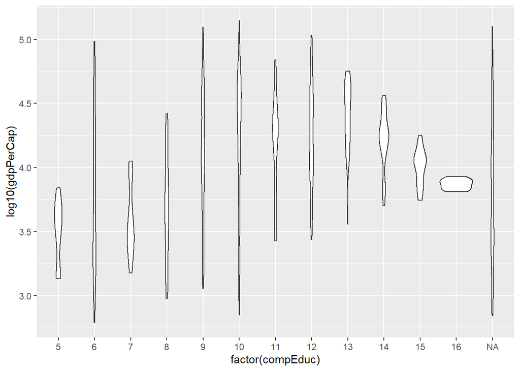

```r
ggplot(data = df) +
    geom_violin(mapping = aes(x = factor(compEduc), y = log10(gdpPerCap)))
```

## Line plots

Let’s say we want to look at how population changes over the time period that we have in our dataset. A natural first try would be the following:

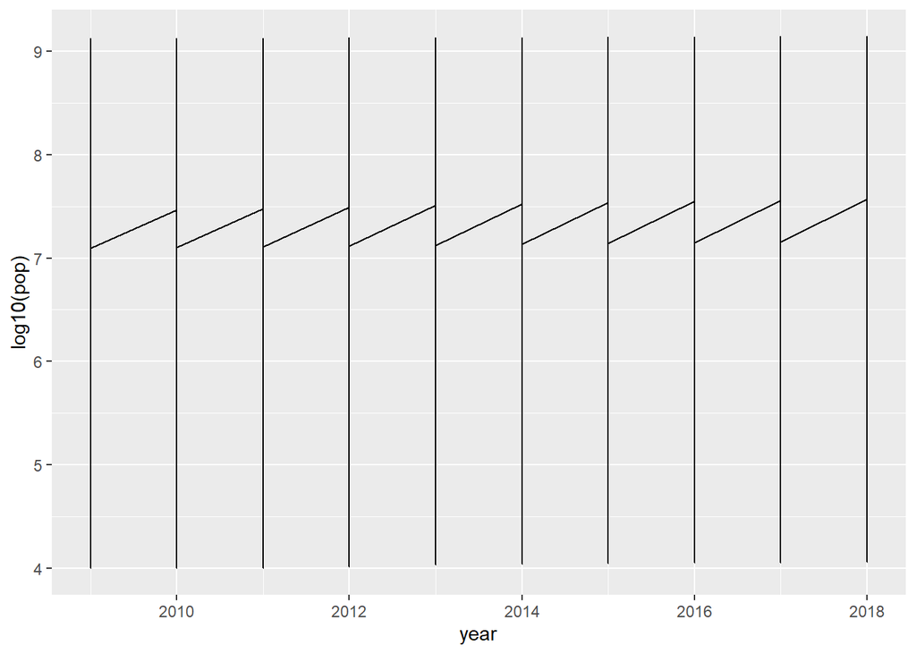

```r
ggplot(data = df) +
    geom_line(aes(x = year, y = log10(pop)))
```

What’s going on here?? What’s happening is that for each value of `year`, there are several rows associated with that value: one for each country! What we really want is one line per country. The way to achieve that is by specifying a `group` option:

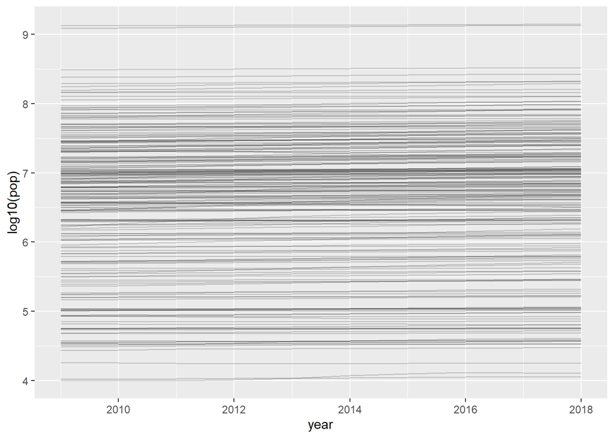

```r
ggplot(data = df) +
    geom_line(aes(x = year, y = log10(pop), group = cty_code), alpha = 0.2)
```

The plot shows that population doesn’t change very much on the log scale, as one might expect. Do we see the same trend with the percentage of the population between 0-14 years?

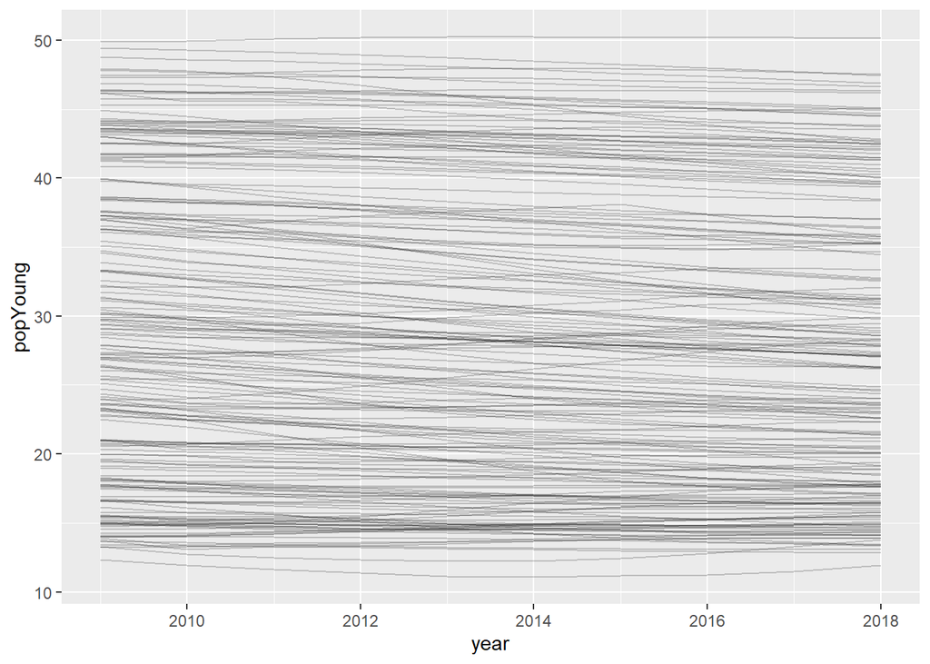

```r
ggplot(data = df) +
    geom_line(aes(x = year, y = popYoung, group = cty_code), alpha = 0.2)
```

There seems to be a slight downward trend.

These plots are not that useful because we are showing data for all the countries on a single plot: it ends up making the plot look like a mess. It might be better to just look at the trends for a handful of countries of interest.

## Relationships between 3 or more variables

Is there a relationship between the total population of a country and the relative proportion of the country being < 15 years old? Let’s make a scatterplot to find out:

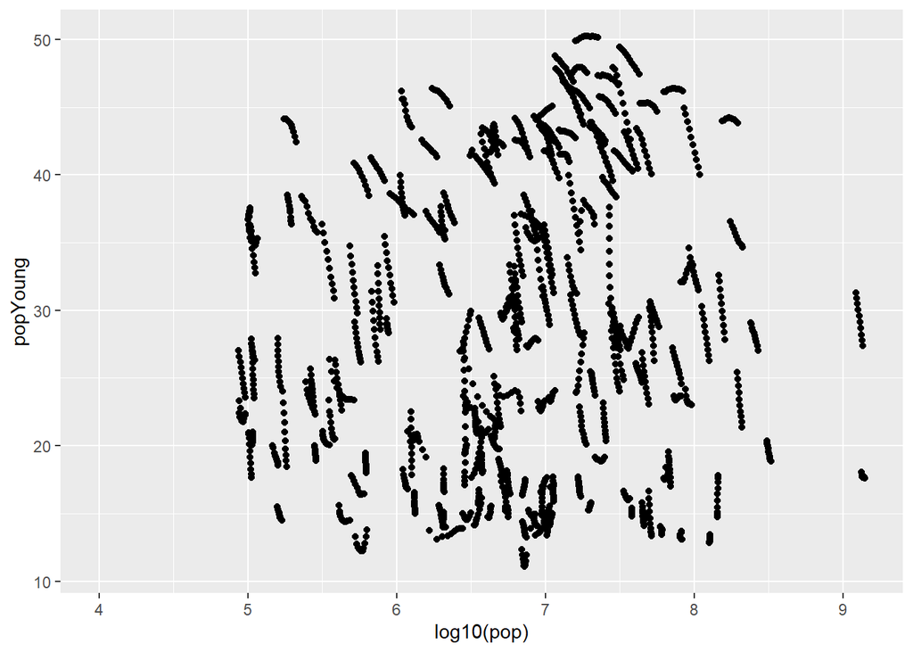

```r
ggplot(data = df) +
    geom_point(aes(x = log10(pop), y = popYoung))
```

That’s an interesting looking plot! We see very clear streaks of points, suggesting that they belong to the same group. One way to test this is to color code the points by the country they belong to:

```r
ggplot(data = df) +
    geom_point(aes(x = log10(pop), y = popYoung), col = cty_code)
```

```
## Error in layer(data = data, mapping = mapping, stat = stat, geom = GeomPoint, : object 'cty_code' not found
```

What went wrong here? Because color depends on data, we should put it within the `aes()` brackets. If `col` is outside the brackets, R interprets our intent as changing the color of all points to `cty_code`. But the variable `cty_code` does not exist in our global environment, hence the error. This is the correct syntax:

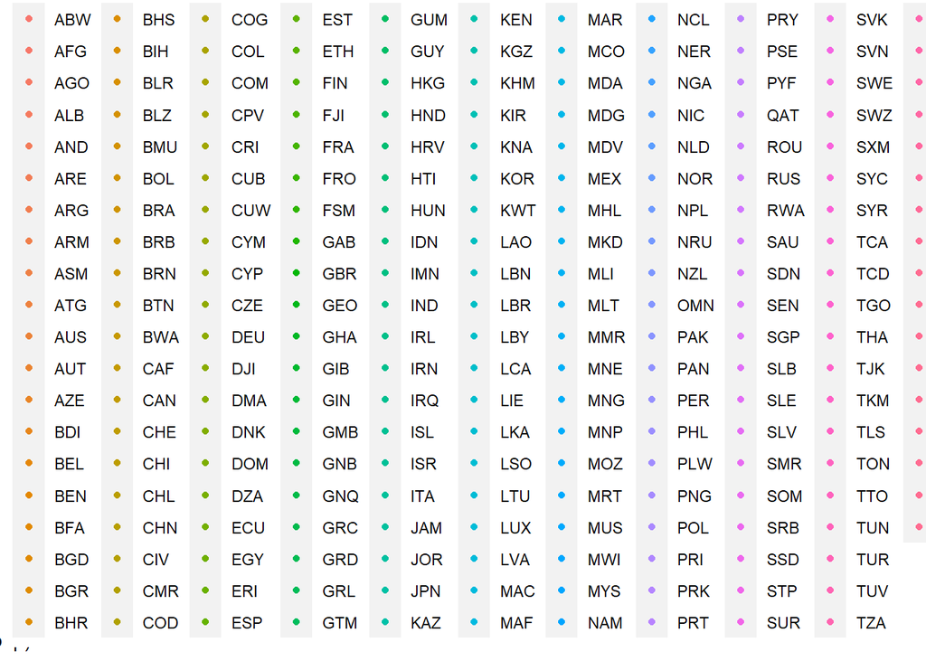

```r
ggplot(data = df) +
    geom_point(aes(x = log10(pop), y = popYoung, col = cty_code))
```

The legend ends up taking up the whole place of the plot… The code below can be used to remove the legend (we’ll learn more about themes next class):

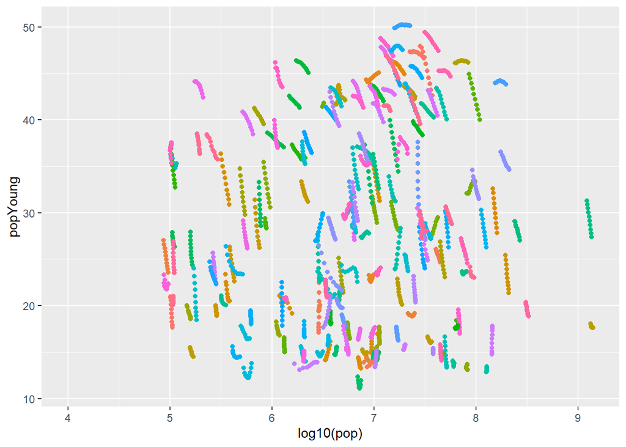

```r
ggplot(data = df) +
    geom_point(aes(x = log10(pop), y = popYoung, col = cty_code)) +
    theme(legend.position = "none")
```

Let’s color the dots by year to see if there is a trend within each streak of dots:

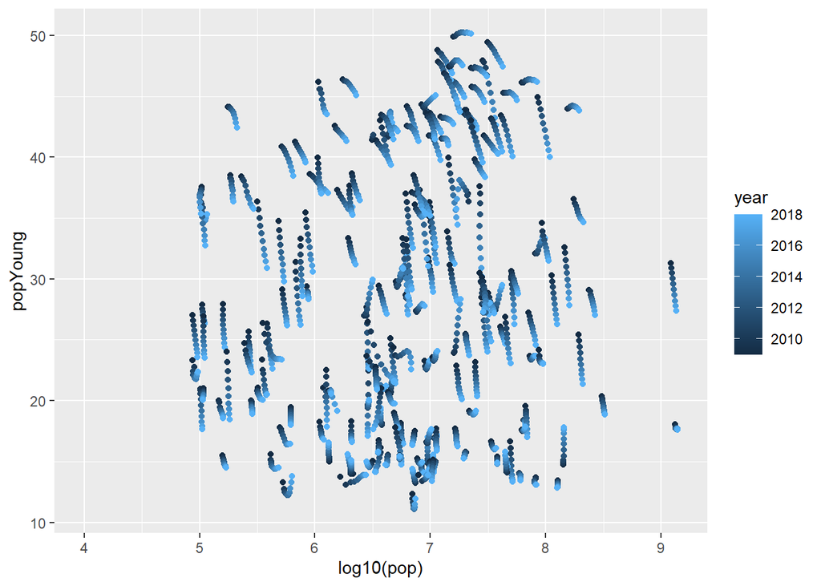

```r
ggplot(data = df) +
    geom_point(aes(x = log10(pop), y = popYoung, col = year))
```